# DEM 7223 - Event History Analysis - Parametric Hazard Models

- Show All Code
- Hide All Code
- View Source

Author

Affiliation

[Corey S. Sparks, PhD](https://coreysparks.github.io)

[The University of Texas at San Antonio](https://hcap.utsa.edu/demography)

Published

September 14, 2022

## Regression modeling of duration data

- Up until now we have not been concerned with the effects of individual characteristics on the risk of experiencing an event.
- We did see earlier that we can express the risk of experiencing an event conditional on individual risk factors, or covariates.
- We first discuss the use of parametric models for doing this

### Parametric models

- When we consider a parametric model in hazards analysis, we are saying that we intend to explicitly define the fundamental shape of our *hazard function*, or that we are assuming a specific distribution for our durations.
- If we make a poor assumption on either of these points, our analysis is often incorrect, because we have effectively defined the wrong model.
- This is bad because our parameters that we think are telling us something, really are telling us nothing.
- We’ve seen this concept before when considering the *Generalized Linear Model* vs the *Linear Model*. i.e. Don’t us the linear model for a binary outcome
- We can use regression models for duration data in two ways:

**Proportional Hazards Model (PH)**

$$h(t_i) = h_0 \text{ } g(x_i)$$
usually letting

$$g(x_i) = \text{exp } (x_i ' \beta)$$

**Accelerated Failure Time Model (AFT)**

$$log(t_i) = x_i ' \beta +z_i$$

letting $z_i$ have a parametric density

### Which model form to use?

What is being modeled? Hazard or time?

- In a proportional hazard model if a $\beta >0$ it says that the hazard increases, if a $\beta <0$ it says that the hazard decreases.
- This is different than we are used to seeing for other regression models
- If the hazard is higher, then the risk is greater. This implies that subjects experience the event at a faster rate, and on average the durations are shorter.

In a accelerated failure time model if a $\beta >0$ it says that the time, or duration increases, if a $\beta <0$ it says that the time, or duration decreases.

This is similar to what we are used to seeing for other regression models.

### Parameters and distributions

Parameters are unknown quantities that we estimate from data.

They define characteristics of mathematical functions, and variations in said functions.

Some examples of parametric models:

Linear regression, using the Normal distribution

$$y \sim Normal (b_0+b_1*x, \sigma^2_e)$$
has 2 parameters, the mean, here shown as the linear mean function, and the variance in the residuals

Logistic regression has mean function that is a transform of the mean

$$y \sim Binomial (p)$$
$$p = \left ( \frac{1}{1+exp^{(b_0+b_1*x)} } \right)$$

In both of these models, we estimate the parameters, $b_0$ and $b_1$ to describe how x affects y

In Parametric hazard models, we estimate regression parameters as well, but we also estimate parameters that describe the *shape of the distribution* of duration times

E.g. the normal distribution function is defined by 2 parameters: $\mu$ and $\sigma$, which define the characteristic bell-shaped curve

### Common distributions in event history analysis

- Exponential This is a 1 parameter distribution, the hazard model for this is:

$$h_i(t,x_i) = h_0 \text{ } exp(x'\beta)$$
The exponential is often a starting point that we don’t use very much. The biggest reason we don’t use it is because the hazard function is assumed to be a constant ($h_0$ isn’t a function of time)

- Weibull The Weibull is a two parameter distribution, it’s hazard function without covariates is:

$$h_i(t) = \theta \gamma t^{\gamma-1}$$

it’s hazard function with covariates is:

$$h_i(t,x_i) = \gamma exp(x'\beta) t^{\gamma-1}$$
You notice that $\theta$ is replaced with the mean function in the second equation. The Weibull is a much more flexible distribution, and the shape of the hazard function change as $\gamma$ changes.

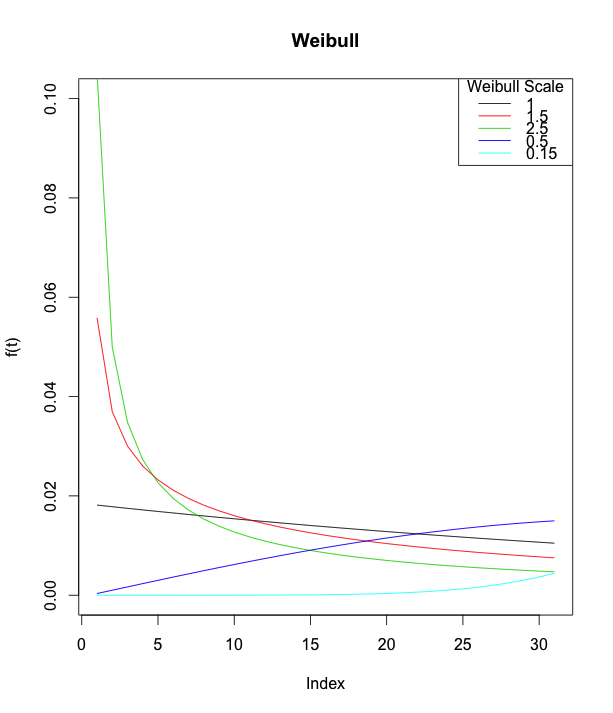

- Log-normal - another 2 parameter distribution, yes, the log of the Normal distribution. Strictly positive. Hazard function is this monster:

$$h(t) = \frac{\frac{1}{t\sigma \sqrt{2\pi}}exp \left [ \frac{-1}{2\sigma^2} {ln(t)-\mu}^2 \right]} {1-\Phi \left \{ \frac{ln(t)- \mu}{\sigma} \right \}}$$
**Yikes!** This is a much more flexible model, because the hazard can actually increase and decrease, which the Weibull cannot do.

- Log-logistic - another 2 parameter distribution, very flexible

$$h(t) = \frac{\lambda \frac{1}{\gamma} t [ \frac{1}{\gamma} -1 ] }
{\gamma [ 1+(\lambda t)^{\frac{1}{\gamma}} ]}$$

**Yikes!**

If $\gamma$ < then the hazard rises, then falls, if $\gamma \geqslant 1$, the hazard is declining The parameter $\lambda$ is the location, and can be parameterized as the linear mean function: $\lambda = e^{-{X'\beta}}$

- Gompertz - very famous demographic model for adult mortality, hazard function is:

$$h(t) = \lambda e^{\gamma t}$$
Where
$$\lambda = e^{X'\beta}$$

In general, more parameters allow for more flexibility to the shape of any distribution, and hence more flexibility when it comes to fitting the distribution to data.

But be aware that more complicated models are not always better than simple ones, and you should compare the fit of the model versus its complexity

Parsimony is the backbone of science!